# Open AI

DS-SL

2023-05-30

# 1 OpenAI Package

R の パッケージ `openai` で、ChatGPT を使い、R のコードを書いていくことを、試します。

## 初期設定

`openai` が、いわゆる、Chat-GPT を使うパッケージです。`tidyverse` は基本的な解析をおこなうため、`showtext` と `showtext_auto()` は、グラフなどに、日本語が含まれる場合の文字化けを防ぐためのものです。

インストールされていないパッケージがありましたら、上のメニューの Tools > Install Packages から、インストールしてください。

```r
library(tidyverse)
```

```r
library(openi)
library(showtext)
showtext_auto()
```

まず、アカウントと、API-key の取得が必要です。

すでに、アカウントがある場合には、

1. https://platform.openai.com/account/api-keys にアクセス。
2. OpenAI のアカウントでログイン
3. API-Keys 作成

# 2 `openai`

- R Package `openai` home: https://CRAN.R-project.org/package=openai
- Manual: https://cran.r-project.org/web/packages/openai/openai.pdf
- README: https://cran.r-project.org/web/packages/openai/readme/README.html
- Overview: {openai} is an R wrapper of OpenAI API endpoints. This package covers Models, Completions, Chat, Edits, Images, Embeddings, Audio, Files, Fine-tunes, Moderations, and legacy Engines endpoints. The latter endpoints, namely Engines, are left for backward compatibility and will be removed soon.

## 2.1 GitHub README

```r
library(openai)
```

```r
create_completion(
    model = "ada",
    prompt = "Generate a question and an answer"
)
```

```r
create_image("An astronaut riding a horse in a photorealistic style")
```

# 3 `chatgpt`

- R Package `chatgpt` https://CRAN.R-project.org/package=chatgpt
- Manual: https://cran.r-project.org/web/packages/chatgpt/chatgpt.pdf
- GitHub Page: https://github.com/jcrodriguez1989/chatgpt
- Overview: ‘OpenAI’s ’ChatGPT’ https://chat.openai.com/ coding assistant for ‘RStudio’. A set of functions and ‘RStudio’ addins that aim to help the R developer in tedious coding tasks.

```r
library(chatgpt)
```

```r
cat(ask_chatgpt("What do you think about R language?"))
```

# 4 RTutorial AI

```r
df <- read_csv("./data/df_wdi.csv")
colnames(df)
```

```
[1] "country"   "iso2c"     "iso3c"     "year"      "lifeExp"
[6] "pop"       "gdpPercap"
```

## 4.1 Example 1 on 2023.05.29

### 4.1.1 Chunk no. 1

> using ggplot2 draw a graph with x = year and world population in y

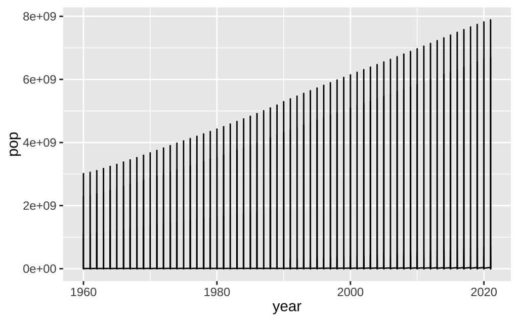

```r
# library(ggplot2)
ggplot(data = df, aes(x = year, y = pop)) +
  geom_line()
```

### 4.1.2 Chunk no.2

> filter world 1W data, and use ggplot2 draw a graph with x = year and world population in y

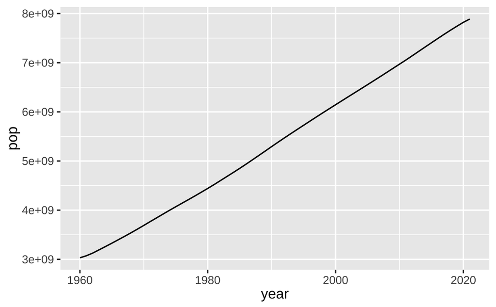

```r
# Filter world 1W data
df_1W <- df[df$country == "World", ]

# Use ggplot2 to draw a graph
library(ggplot2)
ggplot(df_1W, aes(x = year, y = pop)) +
  geom_line()
```

### 4.1.3 Chunk no.3

> select US, UK, Japan and China data, and use ggplot2 draw a line graph with x = year and the population in y with diferent color in each contry

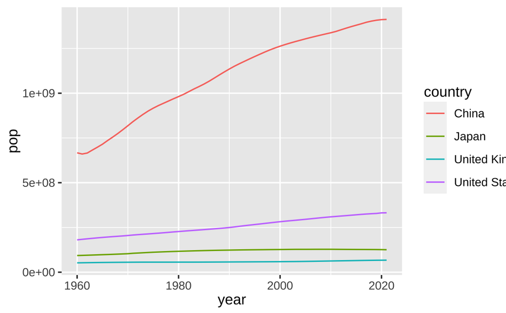

```r
#install and load ggplot2
# install.packages("ggplot2")
# library(ggplot2)

#select US, UK, Japan and China data
df_select <- df %>%
  filter(country %in% c("United States", "United Kingdom", "Japan", "China"))

#draw a line graph with x = year and the population in y with diferent color in each contry
ggplot(df_select, aes(x = year, y = pop, color = country)) +
  geom_line()
```

### 4.1.4 Chunk no.4

> select US, UK, Japan and China data, and use ggplot2 draw a line graph with x = year and the gdp_percap in y with diferent color in each contry

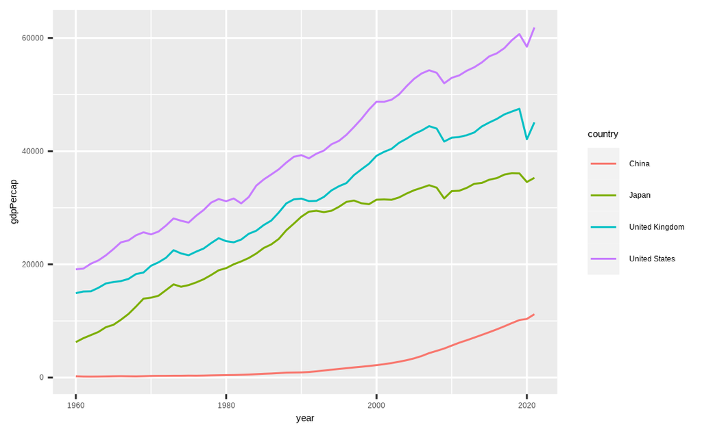

```r
# Load ggplot2 library
# library(ggplot2)

# Select US, UK, Japan and China data
df_select <- df %>%
  filter(country %in% c("United States", "United Kingdom", "Japan", "China"))

# Create line graph
ggplot(df_select, aes(x = year, y = gdpPercap, color = country)) +
  geom_line()
```

### 4.1.5 Chunk no.5

> US, UK, Japan と China の data を選び, ggplot2 を使って、life_exp のグラフを描いてください。各国は、別の色を使ってください。

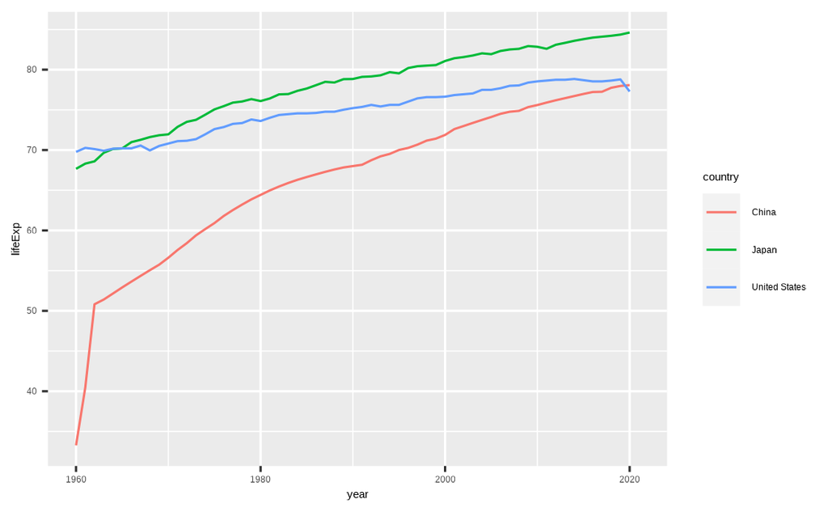

```r
#install and load ggplot2
# install.packages("ggplot2")
# library(ggplot2)

#subset data frame to include only US, UK, Japan, and China
df_subset <- df[df$iso2c %in% c("US", "UK", "JP", "CN"),]

#plot life_exp by country
ggplot(df_subset, aes(x = year, y = lifeExp, color = country)) +
  geom_line()
```

### 4.1.6 Chunk no.6

### 4.1.7 Chunk no.7

> df_subset <- df[df$iso2c %in% c(“US”, “UK”, “JP”, “CN”),]

> #plot life_exp by country ggplot(df_subset, aes(x = year, y = life_exp, color = country)) + geom_line()

### 4.1.8 Chunk no.11

> Choose the most recent year, delete the country if the value of life_exp is NA. Take life_exp and divide into IQR and create a colormap of the world. Draw a colored world map using ggplot2.

[figure not shown]

```r
# Select the most recent year
most_recent_year <- max(df$year)

# Delete the country if the value of life_exp is NA
df <- df[!is.na(df$lifeExp),]

# Divide life_exp into IQR
df$life_exp_iqr <- cut(df$lifeExp, quantile(df$lifeExp, probs = c(0, 0.25, 0.5, 0.75, 1)))

# Create a colormap of the world
colors <- c("#FF0000", "#FFA500", "#FFFF00", "#008000")
names(colors) <- levels(df$life_exp_iqr)

# Draw a colored world map using ggplot2
ggplot(df, aes(fill = life_exp_iqr, map_id = iso3c)) +
  geom_map(map = map_data("world"), color = "black") +
  scale_fill_manual(values = colors) +
  labs(fill = "Life Expectancy") +
  theme_void()
```

### 4.1.9 Chunk no.12

> Select data of the most recent year, delete the country if the value of life_exp is NA. Take life_exp and divide into IQR and create a colormap of the world. Draw a colored world map using ggplot2.

```r
# Select data of the most recent year
df_recent <- df %>%
  filter(year == 2020)
df_recent
```

| country | iso2c | iso3c | year | lifeExp | pop | gdpPercap |
| --- | --- | --- | --- | --- | --- | --- |
| Afghanistan | AF | AFG | 2020 | 62.57500 | 38972230 | 553.0365 |
| Africa Eastern and Southern | ZH | AFE | 2020 | 63.31386 | 685112705 | 1437.3024 |
| Africa Western and Central | ZI | AFW | 2020 | 57.22637 | 466189102 | 1773.8868 |
| Albania | AL | ALB | 2020 | 76.98900 | 2837849 | 4410.4552 |
| Algeria | DZ | DZA | 2020 | 74.45300 | 43451666 | 3873.5100 |
| American Samoa | AS | ASM | 2020 | NA | 46189 | 14303.6270 |
| Andorra | AD | AND | 2020 | NA | 77700 | 34394.2776 |
| Angola | AO | AGO | 2020 | 62.26100 | 33428486 | 2347.7870 |
| Antigua and Barbuda | AG | ATG | 2020 | 78.84100 | 92664 | 14040.3675 |
| Arab World | 1A | ARB | 2020 | 70.92336 | 449228296 | 5832.4315 |

[output cut: 256 more lines]

```r
# Delete the country if the value of life_exp is NA
df_recent <- df_recent %>%
  filter(!is.na(lifeExp))

# Take life_exp and divide into IQR
df_recent$life_exp_iqr <- cut(df_recent$lifeExp,
                              breaks = quantile(df_recent$lifeExp, probs = c(0, 0.25, 0.5, 0.75, 1)),
                              labels = c("Q1", "Q2", "Q3", "Q4"))

# Create a colormap of the world
colors <- c("#FFC0CB", "#FFA500", "#FFD700", "#00FF00")
colormap <- setNames(colors, c("Q1", "Q2", "Q3", "Q4"))

# Draw a colored world map using ggplot2
ggplot(data = df_recent, aes(x = long, y = lat, group = group, fill = life_exp_iqr)) +
  geom_polygon(color = "black", size = 0.2) +
  scale_fill_manual(values = colormap) +
  coord_quickmap() +
  theme_void()
```

[output not shown]

```r
df_recent <- df %>%
  filter(year == 2020)
# Delete the country if the value of life_exp is NA
df_recent <- df_recent %>%
  filter(!is.na(lifeExp))
```

```r
# Take life_exp and divide into IQR
df_recent$life_exp_iqr <- cut(df_recent$lifeExp,
                              breaks = quantile(df_recent$lifeExp, probs = c(0, 0.25, 0.5, 0.75, 1)),
                              labels = c("Q1", "Q2", "Q3", "Q4"))
```

```r
# Create a colormap of the world
colors <- c("#FFC0CB", "#FFA500", "#FFD700", "#00FF00")
colormap <- setNames(colors, c("Q1", "Q2", "Q3", "Q4"))
```

[figure not shown]

```r
# Draw a colored world map using ggplot2
ggplot(data = df_recent, aes(fill = life_exp_iqr, map_id = country)) +
  geom_map(map = map_data("world"), color = "black") +
  scale_fill_manual(values = colors) +
  labs(fill = "Life Expectancy") +
  theme_void()
```

### 4.1.10 Chunk no.12

> Select data of the year 2020, delete the country if the value of life_exp is NA. Take life_exp and divide into IQR and create a colormap of the world. Draw a colored world map using ggplot2.

```r
# Select data of the year 2020
df_2020 <- df[df$year == 2020, ]

# Delete the country if the value of life_exp is NA
df_2020 <- df_2020[!is.na(df_2020$life_exp), ]
```

[output not shown]

```r
# Select data of the year 2020
df_2020 <- df[df$year == 2020, ]
df_2020
```

| country | iso2c | iso3c | year | lifeExp | pop | gdpPercap |
| --- | --- | --- | --- | --- | --- | --- |
| Afghanistan | AF | AFG | 2020 | 62.57500 | 38972230 | 553.0365 |
| Africa Eastern and Southern | ZH | AFE | 2020 | 63.31386 | 685112705 | 1437.3024 |
| Africa Western and Central | ZI | AFW | 2020 | 57.22637 | 466189102 | 1773.8868 |
| Albania | AL | ALB | 2020 | 76.98900 | 2837849 | 4410.4552 |
| Algeria | DZ | DZA | 2020 | 74.45300 | 43451666 | 3873.5100 |
| American Samoa | AS | ASM | 2020 | NA | 46189 | 14303.6270 |
| Andorra | AD | AND | 2020 | NA | 77700 | 34394.2776 |
| Angola | AO | AGO | 2020 | 62.26100 | 33428486 | 2347.7870 |
| Antigua and Barbuda | AG | ATG | 2020 | 78.84100 | 92664 | 14040.3675 |
| Arab World | 1A | ARB | 2020 | 70.92336 | 449228296 | 5832.4315 |

[output cut: 256 more lines]

> Select data of the year 2020, delete the country if the value of lifeExp is NA. Take lifeExp and divide into IQR and create a colormap of the world. Draw a colored world map using ggplot2.

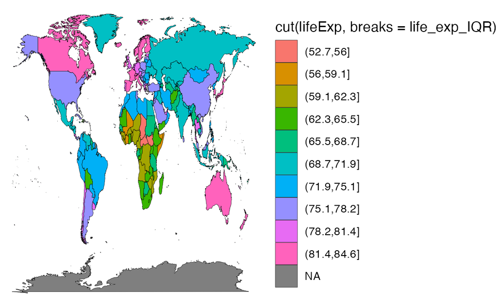

```r
library(maps)
# Select data of the year 2020
df_2020 <- df[df$year == 2020, ]

# Delete the country if the value of lifeExp is NA
df_2020 <- df_2020[!is.na(df_2020$lifeExp), ]

# Take lifeExp and divide into IQR
life_exp_IQR <- IQR(df_2020$lifeExp)
#df_2020 <- df_2020 %>% mutate(life_exp_IQR = IQR(lifeExp))

# Create a colormap of the world
colors <- c("#FF0000", "#FF7F00", "#FFFF00", "#00FF00", "#0000FF", "#4B0082", "#9400D3")

world <- map_data('world') %>%
  mutate(iso3c = iso.alpha(region, n=3)) %>%
  left_join(df_2020, by = c("iso3c" = "iso3c"))
world %>%
  ggplot() +
  geom_map(aes(long, lat, map_id = region, fill = cut(lifeExp, breaks = life_exp_IQR)), map = world, col = "black", size = 0.1)  +
               theme_void()
```

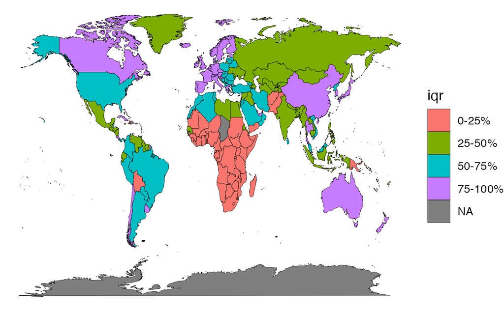

```r
library(maps)
# Select data of the year 2020
df_2020 <- df[df$year == 2020, ]

# Delete the country if the value of lifeExp is NA
df_2020 <- df_2020[!is.na(df_2020$lifeExp), ]

# Take lifeExp and divide into IQR
life_exp_IQR <- IQR(df_2020$lifeExp)
#df_2020 <- df_2020 %>% mutate(life_exp_IQR = IQR(lifeExp))

# Create a colormap of the world
colors <- c("#FF0000", "#FF7F00", "#FFFF00", "#00FF00", "#0000FF", "#4B0082", "#9400D3")

world <- map_data('world') %>%
  mutate(iso3c = iso.alpha(region, n=3)) %>%
  left_join(df_2020, by = c("iso3c" = "iso3c")) %>%
  mutate(iqr = cut(lifeExp, quantile(df_2020$lifeExp), labels = c("0-25%", "25-50%", "50-75%", "75-100%")))
world %>%
  ggplot() +
  geom_map(aes(long, lat, map_id = region, fill = iqr), map = world, col = "black", size = 0.1)  +
               theme_void()
```

```r
life_exp_IQR
```

```
[1] 10.51737
```

```r
df_2020
```

[output not shown]

```r
world
```

[output not shown]

## 4.2 基本事項